# Business Forecasting for fish production in United States

# The histogram is slightly right skewed due to outliers.

```
    Ljung-Box test

data:  Residuals from Random walk
Q* = 5.3312, df = 6, p-value = 0.5021

Model df: 0.   Total lags used: 6
```

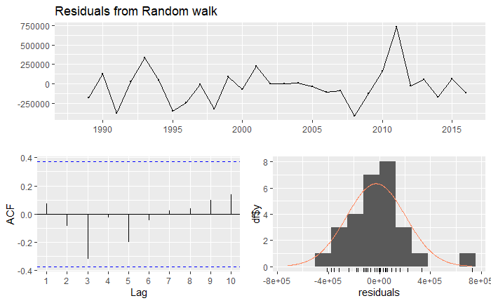

```r
checkresiduals(rwf_forecast)
```

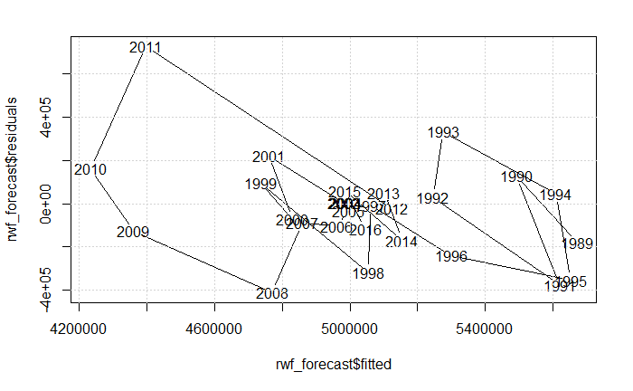

```r
plot(rwf_forecast$fitted,rwf_forecast$residuals)
grid(nx=NULL, ny=NULL)
```

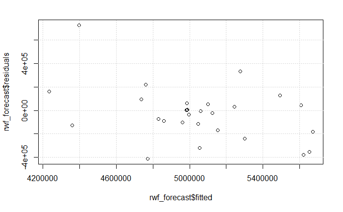

```r
plot.ts(rwf_forecast$fitted,rwf_forecast$residuals,xy.labels = FALSE,xy.lines = FALSE)
grid(nx=NULL, ny=NULL)
```

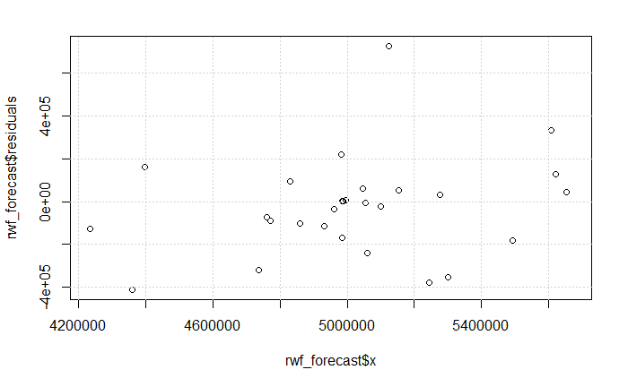

```r
plot.ts(rwf_forecast$x,rwf_forecast$residuals,xy.labels = FALSE,xy.lines = FALSE)
grid(nx=NULL, ny=NULL)
```

# No specific pattern between fitted vs residual and actual vs residual. Plots are somewhat evenly spread.

```r
accuracy(rwf_forecast)
```

```
                    ME     RMSE      MAE        MPE     MAPE MASE       ACF1
Training set -26416.04 228140.4 160037.6 -0.6049683 3.205752    1 0.07203671
```

```r
forecast(rwf_forecast,h=3)
```

|  | Point Forecast | Lo 80 | Hi 80 | Lo 95 | Hi 95 |
| --- | --- | --- | --- | --- | --- |
| 2017 | 4931017 | 4638643 | 5223391 | 4483870 | 5378164 |
| 2018 | 4931017 | 4517538 | 5344496 | 4298656 | 5563378 |
| 2019 | 4931017 | 4424611 | 5437423 | 4156536 | 5705498 |

#RWF end

#Expo Smoothening start

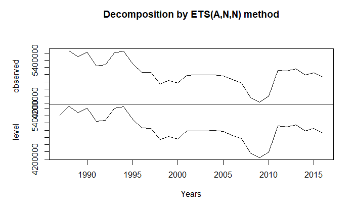

```r
ets_forecast = ets(FP_US_TS_recent)
#plot(ets_forecast, xlab = "Years", yaxt='n')
plot(ets_forecast, xlab = "Years")
```

```r
attributes(ets_forecast)
```

```
$names
 [1] "loglik"     "aic"        "bic"        "aicc"       "mse"        "amse"       "fit"
 [8] "residuals"  "fitted"     "states"     "par"        "m"          "method"     "series"
[15] "components" "call"       "initstate"  "sigma2"     "x"

$class
[1] "ets"
```

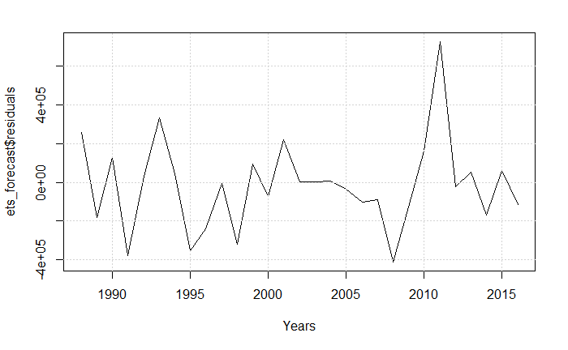

```r
plot(ets_forecast$residuals, xlab = "Years")
grid(nx=NULL, ny=NULL)
```

# The plot is equally spread residuals around the horizontal line without a distinct pattern. This is a good indication it is not a non-linear relationship.

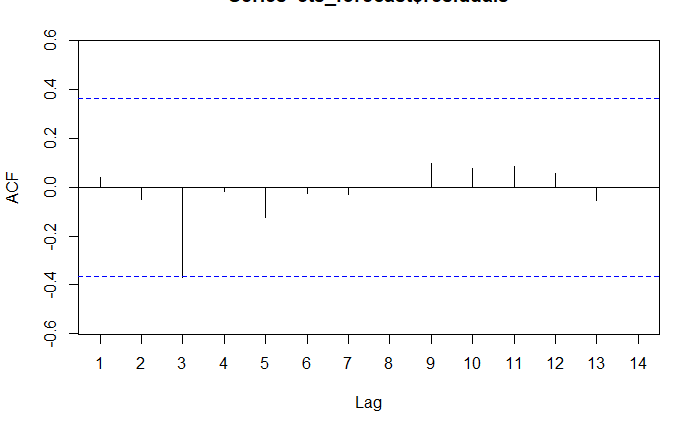

```r
Acf(ets_forecast$residuals)
```

# Here, in the Acf, we don’t see any significant lines which states that there is no correlation between the errors.

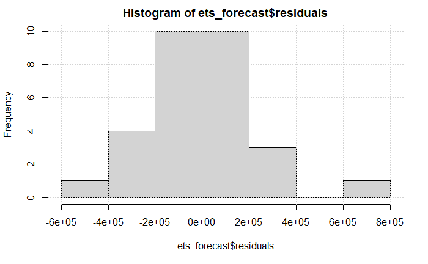

```r
hist(ets_forecast$residuals)
grid(nx=NULL, ny=NULL)
```

# The histogram is slightly right skewed due to outliers.

```
    Ljung-Box test

data:  Residuals from ETS(A,N,N)
Q* = 5.44, df = 4, p-value = 0.2451

Model df: 2.   Total lags used: 6
```

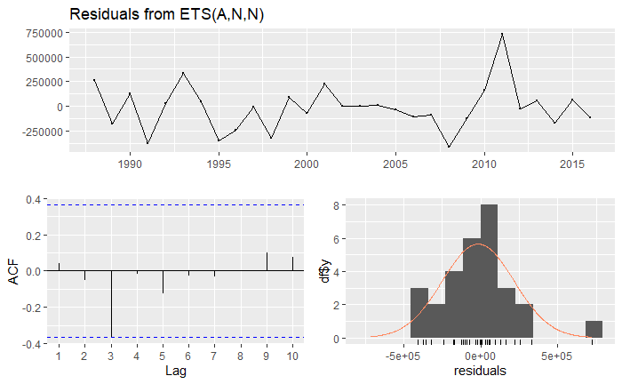

```r
checkresiduals(ets_forecast)
```

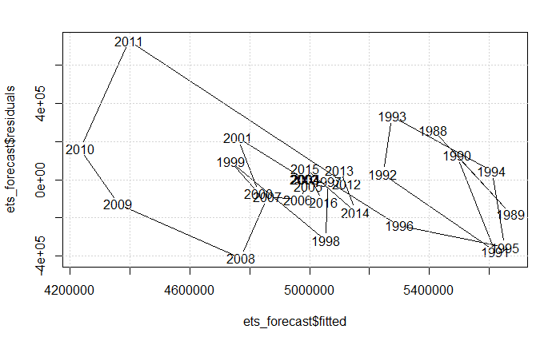

```r
plot(ets_forecast$fitted,ets_forecast$residuals)
grid(nx=NULL, ny=NULL)
```

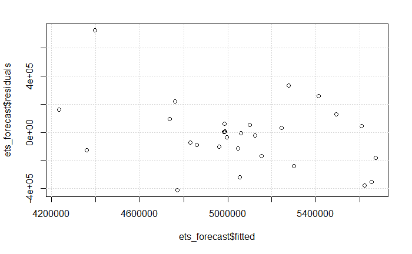

```r
plot.ts(ets_forecast$fitted,ets_forecast$residuals,xy.labels = FALSE,xy.lines = FALSE)
grid(nx=NULL, ny=NULL)
```

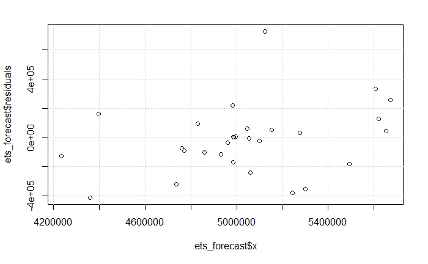

```r
plot.ts(ets_forecast$x,ets_forecast$residuals,xy.labels = FALSE,xy.lines = FALSE)
grid(nx=NULL, ny=NULL)
```